# Final Exam

**Kennedy Lighty**

```r
library(tidyverse)
library(wbstats)
library(broom)
library(modelsummary)
library(marginaleffects)
library(plotly)
library(ggdist)
library(stargazer)
library(dplyr)
library(readr)
```

Please read all of the questions and tables carefully and follow all instructions. Each question has an allotted point value. Be as thorough and specific as possible; extra calculations and incorrect information, even in the presence of correct information, will result in point deductions. Be sure to show all formulas and all necessary work to answer the questions. You may upload your completed exam to the Elms course site.

**Note**

While this is an open-note exam, you are not to receive assistance from anyone else. As usual, the Honor Code applies.

**Total points: 50**

## Conceptual Questions

Please include all work (and computations) necessary to answer the questions.

**Total points: 20 (2 points each)**

### Question 1

Suppose you estimate a bivariate regression model with a total sample size of 50 and obtain a standard error for $\beta_1$ of 2.50. What is the smallest regression coefficient ($\beta_1$) that you could have and still be able to reject the null hypothesis (of no relationship between $X_1$ and $Y$) at the 0.05 level with a one-tailed test?

**The smallest regression that allows for rejection at is 4.19.**

### Question 2

I regress $Y$ on $X_1$ (i.e., $Y = \beta_0 + \beta_1 X_1$) and find that $\beta_1 = 4.20$, $SE_{\beta_1} = 1.90$, $t = 2.21$, $p = 0.01$, and a 95% confidence interval is [0.48, 7.92]. What is my best estimate of the effect of a two-unit change in $X_1$ on the mean of $Y$ in the population?

**The best estimate is 8.40.**

### Question 3

I conduct an OLS regression with a sample size of 90 and 5 independent variables. To determine a p-value for each coefficient, I would examine a t-distribution with how many degrees of freedom?

**I would examine a t-distribution of 84 degrees of freedom.**

### Question 4

Suppose I regress $Y$ on $X$ and compute the mean response for $Y$ at some specified value of $X$. When determining the confidence interval around this mean response, which of the following will **NOT** have any effect on the width (or size) of that confidence interval?

**D**

1. Total sample size,
2. Mean-squared error,
3. The specified value of $X$,
4. **None of the above: all of these (above) will affect the confidence interval,**
5. There is not enough information to answer this question.

### Question 5

I regress $Y$ on $X$ and find that $\beta_1$ has a two-tailed p-value of 0.04. Which of the following statements is most accurate?

**D**

1. The lower and upper bound of a 95% confidence interval around $\beta_1$ will have the same sign,
2. The absolute value for the t-statistic for $\beta_1$ will be greater than 1.96,
3. A 90% confidence interval around $\beta_1$ will not contain zero,
4. **All of the above**
5. None of the above and/or there is not enough information.

### Question 6

I regress $Y$ on three independent variables – $X_1$, $X_2$, and $X_3$ – and I find the following 95% confidence intervals – $\beta_1$: [0.12, 1.45], $\beta_2$: [-0.01, 0.15], and $\beta_3$: [-0.64, -0.01]. Which of the following statements is most accurate?

**E**

1. $\beta_2$ and $\beta_3$ will have negative coefficients, and $\beta_1$ is statistically significant at the 0.05 level (two-tailed),
2. $\beta_1$ will have a positive coefficient, and $\beta_1$ is the only statistically significant coefficient (of the three coefficients) at the 0.05 level (two-tailed),
3. $\beta_1$ will have a positive coefficient, $\beta_2$ and $\beta_3$ will have negative coefficients, and only $\beta_1$ and $\beta_3$ are statistically significant at the 0.05 level (two-tailed),
4. All of the above,
5. **None of the above and/or there is not enough information.**

### Question 7

Suppose I estimate a regression with two independent variables and obtain a $R^2$ of 0.40 where the Residual Sum of Squares is equal to 5,150. What does the Total Sum of Squares equal in this regression model?

**The TSS is 8,583.33.**

### Question 8

I regress $Y$ on $X_1$ and $X_2$ (i.e., $Y = \beta_0 + \beta_1 X_1 + \beta_2 X_2$). I find that $\beta_1 = -0.87$ with a two-tailed p value of 0.001 and $\beta_2 = 3.52$ with a two-tailed p-value of 0.04. Which of the following statements is most accurate?

**A**

1. $X_2$ **has a larger substantive effect on** $Y$ **than** $X_1$**, but the effect of** $X_1$ **is more statistically significant**
2. $X_1$ has a larger substantive effect on $Y$ than $X_2$ and $X_1$ is more statistically significant than $X_2$,
3. $X_1$ has a larger substantive effect on $Y$ than $X_2$, but the effect of $X_2$ is more statistically significant,
4. None of the above and/or there is not enough information.

### Question 9

I regress $Y$ on $X_1$ (i.e., $Y = \beta_0 + \beta_1 X_1$) and obtain a $R^2$ of 0.45. Then, I regress $Y$ on both $X_1$ and $X_2$ (i.e., $Y = \beta_0 + \beta_1 X_1 + \beta_2 X_2$) and obtain a $R^2$ of 0.53. Which of the following statements must be true?

**C**

1. The correlation between $X_1$ and $Y$ is stronger than the correlation between $X_2$ and $Y$,
2. The coefficient on $\beta_1$ is statistically significant in both models,
3. **The model with** $X_1$ **and** $X_2$ **explains more of the variation in** $Y$ **than a model with just** $X_1$**,**
4. All of the above: all of these statements are true.

### Question 10

Based on the following regression equation, might the negative coefficient on the South variable be the result of southern states having a lower proportion of high school graduates than non-southern states? In no more than one sentence, explain your answer.

$$Turnout = 34 + 0.5(Percent\ High\ School\ Graduates) – 5.9(South)$$

**Yes, since the regression already takes into account the influence of the percentage of high school graduates, it is possible that the negative coefficient on the south variable is caused by the lower proportion of high school graduates in southern states. This would isolate the distinct contribution of being a southern state to lower turnout.**

## Applied Questions

All datasets referenced below are posted on the ELMs course site.

### Question 1

*Points: 15*

Use the `world` dataset to answer the following questions. The relevant variables and their coding information are as follows: `literacy` indicates a country’s literacy rate; `dem_score14` represents a country’s level of democratization (higher values indicate greater democratization); `spendeduc` reflects the amount of public expenditures on education as a percentage of GDP; `gdp_10_thou` represents GDP per capita (one unit is $10,000 USD); `educ_quality` indicates the average quality rating of a country’s educational system; and `ungr9095` represents the percent average annual population growth.

#### Part A

*Points: 4*

Evaluate the bivariate relationship (using R) between a country’s support for public education and its literacy rate. Report the results in a professionally formatted table. Do countries that spend more money on education appear to have a higher literacy rate?

```r
world <- read_csv("world.csv")

summary(lm(literacy ~ spendeduc, data = world))
```

```
Call:
lm(formula = literacy ~ spendeduc, data = world)

Residuals:
    Min      1Q  Median      3Q     Max
-59.391 -11.024   9.323  15.967  22.258

Coefficients:
            Estimate Std. Error t value Pr(>|t|)
(Intercept)  73.2698     4.2568  17.212   <2e-16 ***
spendeduc     1.7220     0.8731   1.972   0.0505 .
---
Signif. codes:  0 '***' 0.001 '**' 0.01 '*' 0.05 '.' 0.1 ' ' 1

Residual standard error: 20.3 on 140 degrees of freedom
  (27 observations deleted due to missingness)
Multiple R-squared:  0.02704,   Adjusted R-squared:  0.02009
F-statistic:  3.89 on 1 and 140 DF,  p-value: 0.05054
```

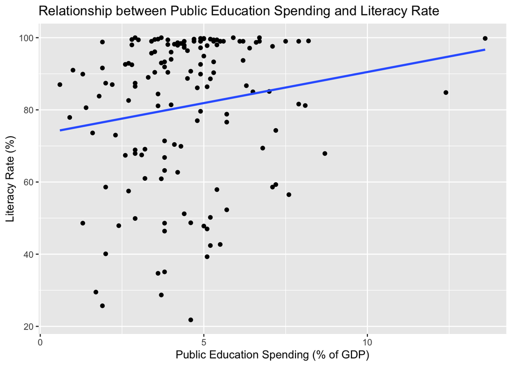

```r
ggplot(world, aes(x = spendeduc, y = literacy)) +
  geom_point() +
  geom_smooth(method = "lm", se = FALSE) +
  labs(title = "Relationship between Public Education Spending and Literacy Rate",
       x = "Public Education Spending (% of GDP)",
       y = "Literacy Rate (%)")
```

```r
model <- lm(literacy ~ spendeduc, data = world)
stargazer(model, type = "text", title = "Bivariate Relationship between Public Education Spending and Literacy Rate",
          dep.var.labels = "Literacy Rate", covariate.labels = "Public Education Spending (% of GDP)")
```

```
Bivariate Relationship between Public Education Spending and Literacy Rate
================================================================
                                         Dependent variable:
                                     ---------------------------
                                            Literacy Rate
----------------------------------------------------------------
Public Education Spending (% of GDP)           1.722*
                                               (0.873)

Constant                                      73.270***
                                               (4.257)

----------------------------------------------------------------
Observations                                     142
R2                                              0.027
Adjusted R2                                     0.020
Residual Std. Error                       20.300 (df = 140)
F Statistic                             3.890* (df = 1; 140)
================================================================
Note:                                *p<0.1; **p<0.05; ***p<0.01
```

**The data would suggest that countries that spend more on education have higher literacy rates.**

#### Part B

*Points: 5*

Estimate a second regression model (using R) that includes both a country’s public expenditures on education and its level of democratization as independent variables. When controlling for democratization, does education expenditures exhibit a significant impact on literacy? Report the results in a professionally formatted table. Be sure to discuss the extent to which the results change, and if so, why they changed.

```r
world_data_clean <- na.omit(world[, c("spendeduc", "literacy", "dem_score14")])
summary(world_data_clean)
```

```
   spendeduc         literacy       dem_score14
 Min.   : 0.600   Min.   : 21.80   Min.   :1.490
 1st Qu.: 3.225   1st Qu.: 68.15   1st Qu.:3.570
 Median : 4.350   Median : 88.85   Median :5.790
 Mean   : 4.468   Mean   : 80.96   Mean   :5.614
 3rd Qu.: 5.300   3rd Qu.: 98.35   3rd Qu.:7.438
 Max.   :13.600   Max.   :100.00   Max.   :9.930
```

```r
model2 <- lm(literacy ~ spendeduc + dem_score14, data = world_data_clean)
summary(model2)
```

```
Call:
lm(formula = literacy ~ spendeduc + dem_score14, data = world_data_clean)

Residuals:
    Min      1Q  Median      3Q     Max
-52.109  -9.593   3.819  11.272  33.873

Coefficients:
            Estimate Std. Error t value Pr(>|t|)
(Intercept)  53.7017     4.8278  11.124  < 2e-16 ***
spendeduc     0.2582     0.8020   0.322    0.748
dem_score14   4.6504     0.7226   6.435 1.85e-09 ***
---
Signif. codes:  0 '***' 0.001 '**' 0.01 '*' 0.05 '.' 0.1 ' ' 1

Residual standard error: 17.88 on 139 degrees of freedom
Multiple R-squared:  0.2504,    Adjusted R-squared:  0.2396
F-statistic: 23.21 on 2 and 139 DF,  p-value: 2.002e-09
```

```r
stargazer(model2, type = "text", title = "Regression: Literacy Rate vs. Education Spending and Democratization",
          dep.var.labels = "Literacy Rate",
          covariate.labels = c("Public Education Spending", "Democratization Level"))
```

```
Regression: Literacy Rate vs. Education Spending and Democratization
=====================================================
                              Dependent variable:
                          ---------------------------
                                 Literacy Rate
-----------------------------------------------------
Public Education Spending            0.258
                                    (0.802)

Democratization Level              4.650***
                                    (0.723)

Constant                           53.702***
                                    (4.828)

-----------------------------------------------------
Observations                          142
R2                                   0.250
Adjusted R2                          0.240
Residual Std. Error            17.882 (df = 139)
F Statistic                 23.214*** (df = 2; 139)
=====================================================
Note:                     *p<0.1; **p<0.05; ***p<0.01
```

#### Part C

*Points: 6*

Now estimate a third model (using R) that includes all of the variables listed above. Report the regression results in a professionally formatted table and interpret each coefficient. When interpreting the impact of democratization using this regression model, present/utilize a visual representation (using R) of the expected change in literacy as a function of democratization.

```r
variables <- c("literacy", "spendeduc", "dem_score14", "gdp_10_thou", "educ_quality", "ungr9095")

world_data_clean <- na.omit(world[, variables])

summary(world_data_clean)
```

```
    literacy        spendeduc       dem_score14     gdp_10_thou
 Min.   : 21.80   Min.   : 1.000   Min.   :1.500   Min.   :0.00900
 1st Qu.: 70.03   1st Qu.: 3.425   1st Qu.:4.022   1st Qu.:0.04925
 Median : 90.35   Median : 4.400   Median :6.090   Median :0.19200
 Mean   : 82.16   Mean   : 4.496   Mean   :5.866   Mean   :0.69947
 3rd Qu.: 98.78   3rd Qu.: 5.300   3rd Qu.:7.607   3rd Qu.:0.64400
 Max.   :100.00   Max.   :12.400   Max.   :9.930   Max.   :4.73500
  educ_quality      ungr9095
 Min.   :1.918   Min.   :-5.500
 1st Qu.:3.128   1st Qu.: 0.525
 Median :3.541   Median : 1.700
 Mean   :3.705   Mean   : 1.493
 3rd Qu.:4.247   3rd Qu.: 2.575
 Max.   :5.982   Max.   : 5.600
```

```r
model3 <- lm(literacy ~ spendeduc + dem_score14 + gdp_10_thou + educ_quality + ungr9095, data = world_data_clean)
summary(model3)
```

```
Call:
lm(formula = literacy ~ spendeduc + dem_score14 + gdp_10_thou +
    educ_quality + ungr9095, data = world_data_clean)

Residuals:
    Min      1Q  Median      3Q     Max
-46.171  -5.953   3.517  10.789  28.566

Coefficients:
             Estimate Std. Error t value Pr(>|t|)
(Intercept)   55.9103     8.8978   6.284 5.98e-09 ***
spendeduc      0.1124     0.9232   0.122 0.903342
dem_score14    2.5456     0.9166   2.777 0.006395 **
gdp_10_thou    2.3598     2.0221   1.167 0.245593
educ_quality   3.8118     2.2053   1.728 0.086568 .
ungr9095      -3.3259     0.9460  -3.516 0.000626 ***
---
Signif. codes:  0 '***' 0.001 '**' 0.01 '*' 0.05 '.' 0.1 ' ' 1

Residual standard error: 16.21 on 116 degrees of freedom
Multiple R-squared:  0.3666,    Adjusted R-squared:  0.3393
F-statistic: 13.43 on 5 and 116 DF,  p-value: 2.492e-10
```

```r
stargazer(model3, type = "text",
          title = "Regression Results: Literacy Rate vs. All Independent Variables",
          dep.var.labels = "Literacy Rate",
          covariate.labels = c("Public Education Expenditures (%)", "Level of Democratization",
                               "GDP per Capita (in $10,000s)", "Education Quality",
                               "Population Growth Rate (1990-95)"))
```

```
Regression Results: Literacy Rate vs. All Independent Variables
=============================================================
                                      Dependent variable:
                                  ---------------------------
                                         Literacy Rate
-------------------------------------------------------------
Public Education Expenditures (%)            0.112
                                            (0.923)

Level of Democratization                   2.546***
                                            (0.917)

GDP per Capita (in 10,000s)                  2.360
                                            (2.022)

Education Quality                           3.812*
                                            (2.205)

Population Growth Rate (1990-95)           -3.326***
                                            (0.946)

Constant                                   55.910***
                                            (8.898)

-------------------------------------------------------------
Observations                                  122
R2                                           0.367
Adjusted R2                                  0.339
Residual Std. Error                    16.213 (df = 116)
F Statistic                         13.430*** (df = 5; 116)
=============================================================
Note:                             *p<0.1; **p<0.05; ***p<0.01
```

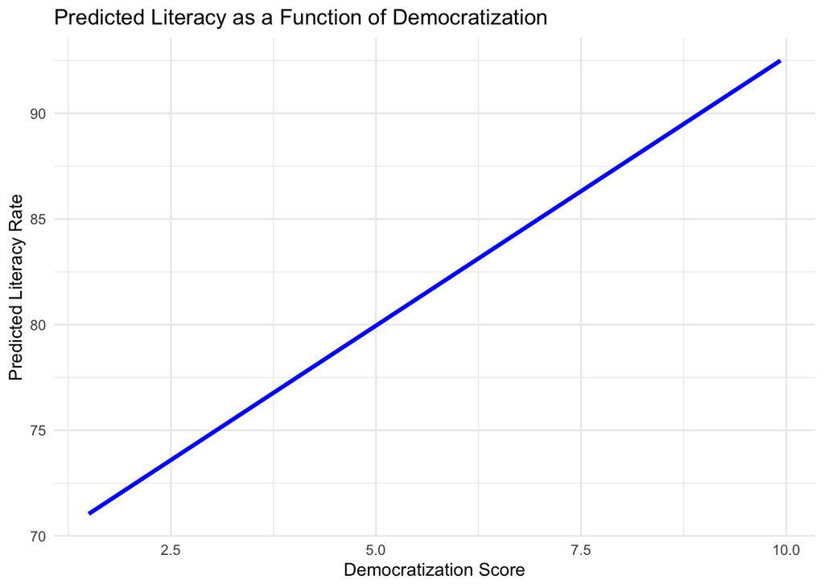

```r
visual_data <- data.frame(
  dem_score14 = seq(min(world_data_clean$dem_score14), max(world_data_clean$dem_score14), length.out = 100),
  spendeduc = mean(world_data_clean$spendeduc),
  gdp_10_thou = mean(world_data_clean$gdp_10_thou),
  educ_quality = mean(world_data_clean$educ_quality),
  ungr9095 = mean(world_data_clean$ungr9095)
)
visual_data$predicted_literacy <- predict(model3, newdata = visual_data)

ggplot(visual_data, aes(x = dem_score14, y = predicted_literacy)) +
  geom_line(color = "blue", size = 1.2) +
  labs(title = "Predicted Literacy as a Function of Democratization",
       x = "Democratization Score",
       y = "Predicted Literacy Rate") +
  theme_minimal()
```